# **MATH 3190 Homework 1**

Due January 29, 2026  
Focus: Notes 1-3  
Total Points: 90 + 10 (Self-Critique Comment and Uploading to GitHub) = 100

Note that your homework should be completed in Quarto. You can just add your answers and code to this document in the appropriate part. The file should be rendered as an html document or pdf document (html is quicker to render and you will need an installation of LaTeX to render as a pdf). You will “turn in” this homework by uploading the files, the .qmd and output file, to your GitHub `Math_3190_Assignment` repository in the `Homework/Homework_1` directory. Make sure all supporting files (if there are any) are in this directory as well. You should use `git` and `Unix` commands in a terminal for this (i.e. don’t manually upload files to GitHub). In addition, you will submit just your html or pdf file on Canvas to unlock the solutions.

Don’t forget to also put a self-critique comment on Canvas indicating what you did correctly and incorrectly and include any questions you may have about the assignment after submitting the assignment and thoroughly looking through the solutions.

# Problem 1 (18 points)

In two different code chunks, write two functions called `gghist` and `ggbox`. The first code chunk is already given below, but you’ll need to add the second one. The `gghist` function should create a ggplot histogram of a variable that is given as a vector. The `ggbox` function should create a ggplot box plot when a single numeric vector is given or it should create side-by-side box plots if one numeric and one categorical variables are given. You can check if a vector is numeric with the `is.numeric()` function. Allow the user to indicate whether it should be horizontal or vertical box plots. Make sure you set `echo` and `eval` both to `true` for these code chunks. Also make sure to label the code chunks.

```r
library(ggplot2)

gghist <- function(vec) {
  df <- data.frame(x = vec)

  ggplot(df, aes(x = x)) +
    geom_histogram()
}
```

```r
ggbox=function(x, group=NULL, horizontal= FALSE){
  if (!is.numeric(x)){
    stop("x must be numeric")
  }
  if (is.null(group)){df=data.frame(x=x)
    plot=ggplot(df,aes(y=x))+geom_boxplot()
  }else{
    df=data.frame(x=x, group=group)
    p=ggplot(df, aes(x=group, y=x))+geom_boxplot()
  }
  if (horizontal) {p=p +coord_flip()}
return(p)}
```

# Problem 2 (57 points)

### Part a (6 points)

```r
library(tidyverse)
download.file("http://kenpom.com/cbbga26.txt", "cbbga26.txt")
cbbga=read.fwf("cbbga26.txt", widths=c(10,24,3,24,3,50),
strip.white=TRUE)
#| convert to tibble
cbbga=as_tibble(cbbga)
```

```r
cbbga2=cbbga|>rename(date=V1, away_team=V2, away_score=V3, home_team=V4, home_score=V5, other=V6)
head(cbbga2,6)
```

```
# A tibble: 6 × 6
  date       away_team     away_score home_team         home_score other
  <chr>      <chr>              <int> <chr>                  <int> <chr>
1 11/03/2025 McMurry               55 Abilene Christian         92 ""
2 11/03/2025 James Madison         71 Akron                     85 ""
3 11/03/2025 North Dakota          62 Alabama                   91 ""
4 11/03/2025 Blue Mountain         60 Alabama A&M               80 ""
5 11/03/2025 Florida               87 Arizona                   93 "N   Las Veg…
6 11/03/2025 Southern              77 Arkansas                 109 ""
```

### Part c (2 points)

Use `mutate()` to create a new column that gives the score differences (home team score minus away team score). Then print the first six rows of the new tibble using the `head()` function.

```r
cbbga3=cbbga2|>mutate(score_difference=home_score-away_score)
head(cbbga3,6)
```

```
# A tibble: 6 × 7
  date       away_team    away_score home_team home_score other score_difference
  <chr>      <chr>             <int> <chr>          <int> <chr>            <int>
1 11/03/2025 McMurry              55 Abilene …         92 ""                  37
2 11/03/2025 James Madis…         71 Akron             85 ""                  14
3 11/03/2025 North Dakota         62 Alabama           91 ""                  29
4 11/03/2025 Blue Mounta…         60 Alabama …         80 ""                  20
5 11/03/2025 Florida              87 Arizona           93 "N  …                6
6 11/03/2025 Southern             77 Arkansas         109 ""                  32
```

### Part d (2 points)

Use `arrange()` to sort the data set by the home team alphabetically. Then print the first six rows of the new tibble using the `head()` function.

```r
cbbga4=cbbga3|>arrange(home_team)
head(cbbga4,6)
```

```
# A tibble: 6 × 7
  date       away_team    away_score home_team home_score other score_difference
  <chr>      <chr>             <int> <chr>          <int> <chr>            <int>
1 11/03/2025 McMurry              55 Abilene …         92 ""                  37
2 11/06/2025 Nebraska Om…         71 Abilene …         73 ""                   2
3 11/11/2025 Southwester…         63 Abilene …        104 ""                  41
4 11/25/2025 William & M…         92 Abilene …         58 "N  …              -34
5 11/28/2025 Jarvis Chri…         55 Abilene …         87 ""                  32
6 12/06/2025 New Mexico …         69 Abilene …         77 ""                   8
```

### Part e (2 points)

Use `select()` to remove the extra variable(s) that had that irrelevant information at the end of each line. Note: you can select every variable except one by using `!`. Then print the first six rows of the new tibble using the `head()` function.

```r
cbbga5=cbbga4|>select(!other)
head(cbbga5,6)
```

```
# A tibble: 6 × 6
  date       away_team          away_score home_team home_score score_difference
  <chr>      <chr>                   <int> <chr>          <int>            <int>
1 11/03/2025 McMurry                    55 Abilene …         92               37
2 11/06/2025 Nebraska Omaha             71 Abilene …         73                2
3 11/11/2025 Southwestern Adve…         63 Abilene …        104               41
4 11/25/2025 William & Mary             92 Abilene …         58              -34
5 11/28/2025 Jarvis Christian           55 Abilene …         87               32
6 12/06/2025 New Mexico St.             69 Abilene …         77                8
```

### Part f (3 points)

Put parts a-e all together in one piping expression (with 5 pipes) and save this as a new object in **R**.

```r
cbbga_all <- read.fwf(file = "http://kenpom.com/cbbga26.txt",widths = c(10, 24, 3, 24, 3, 40),strip.white = TRUE) |>
as_tibble() |>rename(date = V1,away_team = V2,away_score = V3,home_team = V4,home_score = V5,other = V6) |>
mutate(score_difference = home_score - away_score) |>
arrange(home_team) |>select(!other)
head(cbbga_all,6)
```

```
# A tibble: 6 × 6
  date       away_team          away_score home_team home_score score_difference
  <chr>      <chr>                   <int> <chr>          <int>            <int>
1 11/03/2025 McMurry                    55 Abilene …         92               37
2 11/06/2025 Nebraska Omaha             71 Abilene …         73                2
3 11/11/2025 Southwestern Adve…         63 Abilene …        104               41
4 11/25/2025 William & Mary             92 Abilene …         58              -34
5 11/28/2025 Jarvis Christian           55 Abilene …         87               32
6 12/06/2025 New Mexico St.             69 Abilene …         77                8
```

### Part g (3 points)

Use `filter()` to reduce the data down to only games played in 2025 (you could use the `lubridate` package for this, since it specializes in dealing with dates, but some base **R** packages will also work). Save this in a new tibble. **We will use this tibble with only the 2025 years from here on out**.

```r
library(lubridate)
library(dplyr)
cbbga_2025 <- cbbga_all |> mutate(date = mdy(date)) |> filter(year(date) == 2025)
```

### Part h (4 points)

Write a function that will filter the tibble to only games played by a given team. Demonstrate your function by displaying games played by SUU in 2025.

```r
filter_teams=function(data,team){data|>filter(home_team==team | away_team==team)}
filter_teams(cbbga_2025, "Southern Utah")
```

```
# A tibble: 14 × 6
   date       away_team         away_score home_team home_score score_difference
   <date>     <chr>                  <int> <chr>          <int>            <int>
 1 2025-11-04 Southern Utah             64 Arizona …         81               17
 2 2025-11-17 Southern Utah             50 Gonzaga          122               72
 3 2025-11-15 Southern Utah             85 Nebraska…         90                5
 4 2025-12-18 Southern Utah             57 Northern…         65                8
 5 2025-12-06 Southern Utah             70 Oregon S…         81               11
 6 2025-11-28 Southern Utah             54 Robert M…         61                7
 7 2025-11-08 UT Rio Grande Va…         95 Southern…         72              -23
 8 2025-11-11 Bethesda                  60 Southern…        118               58
 9 2025-11-22 Nobel                     68 Southern…        103               35
10 2025-12-01 West Coast Bapti…         59 Southern…        124               65
11 2025-11-29 Southern Utah             70 Stetson           68               -2
12 2025-12-29 Southern Utah             66 Utah Tech         80               14
13 2025-12-13 Southern Utah             69 Washingt…        105               36
14 2025-11-19 Southern Utah             74 Washingt…         98               24
```

### Part i (7 points)

Use `summarize()` to extract SUU’s win/loss record and winning percentage for their 2025 games. Hint: using the `case_when()` function inside of a `mutate()` function to create a new variable that indicates whether SUU won or lost is helpful. You can verify on the Internet that SUU had 4 wins and 10 losses in 2025, so if your code retruns those values, you did it correctly.

```r
library(dplyr)
library(stringr)
cbbga_2025 |> filter(home_team == "Southern Utah" | away_team == "Southern Utah") |>
mutate(result = case_when(home_team == "Southern Utah" & score_difference > 0 ~ "win",home_team == "Southern Utah" & score_difference < 0 ~ "loss",
away_team == "Southern Utah" & score_difference < 0 ~ "win",away_team == "Southern Utah" & score_difference > 0 ~ "loss")) |>
summarize(wins = sum(result == "win", na.rm = TRUE),losses = sum(result == "loss", na.rm = TRUE),winning_percent = wins / (wins + losses))
```

```
# A tibble: 1 × 3
   wins losses winning_percent
  <int>  <int>           <dbl>
1     4     10           0.286
```

### Part j (7 points)

Generalize this by writing a function that will do this for a given team, and create a tibble with this information for all teams. Arrange this tibble first by winning percentage (descending) and by team (alphabetically) if there are any ties when it comes to winning percentage. A `for` loop and the `add_row()` function may be useful here.

```
team_summary <- function(data, team) {
  data |>
    filter(home_team == team | away_team == team) |>
    mutate(
      result = case_when(
        home_team == team & score_difference > 0 ~ "win",
        home_team == team & score_difference < 0 ~ "loss",
        away_team == team & score_difference < 0 ~ "win",
        away_team == team & score_difference > 0 ~ "loss",
        TRUE ~ NA_character_
      )
    ) |>
    summarize(
      team = team,
      wins = sum(result == "win", na.rm = TRUE),
      losses = sum(result == "loss", na.rm = TRUE)
    ) |>
    mutate(winning_pct = wins / (wins + losses))
}

teams <- sort(unique(c(cbbga_2025$home_team, cbbga_2025$away_team)))

records <- tibble(
  team = character(),
  wins = integer(),
  losses = integer(),
  winning_pct = double()
)

for (value in teams) {
  team_record <- team_summary(cbbga_2025, value)
  records <- add_row(
    records,
    team = team_record$team,
    wins = team_record$wins,
    losses = team_record$losses,
    winning_pct = team_record$winning_pct
  )
}

records <- records |>
  arrange(desc(winning_pct), team)
```

### Part k (5 points)

With only the 2025 games, use the `gghist()` you wrote in Problem 1 on the score differences variable you created in part c. Add appropriate labels and a title to your graph. Also, use the `#| fig-width:`, `#| fig-height:`, `#| out-width:`, and `#| fig-align:` code chunk options to center the figure and then to adjust your figure to a size you like. Play around with different sizes to see what those options adjust.

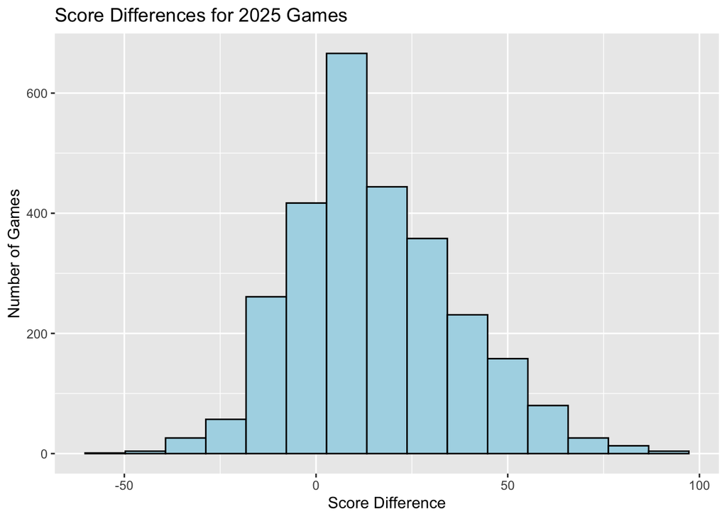

```r
gghist <- function(vec) {df <- data.frame(x = vec)
ggplot(df, aes(x = x)) + geom_histogram(bins=15,color="black",fill="lightblue") +
labs(x = "Score Difference",y = "Number of Games",title="Score Differences for 2025 Games")}
#| fig-width: 8
#| fig-height: 4
#| out-width: "80%"
#| fig-align: center
gghist(cbbga_2025$score_difference)
```

### Part l (9 points)

Filter the tibble with all 2025 games to only include Utah Tech or Southern Utah, then crate a tibble or data frame where each row is a game played by either team that has one column indicating the school, Utah Tech or Southern Utah, and a second column indicating the number of points that team played, regardless of whether the team was home or away. Then use your `ggbox()` function to create a side-by-side boxplot of number of points scored in all 2025 games for each team.

Note, this is a little challenging. The most straightforward way to do this is to use the `pivot_longer()` function with `cols =` the names of the two columns that have the away and the home teams (the names of these columns should not be in quotes, but they should be in a vector `c()`). Try to do this yourself first, but using AI for some help is fine.

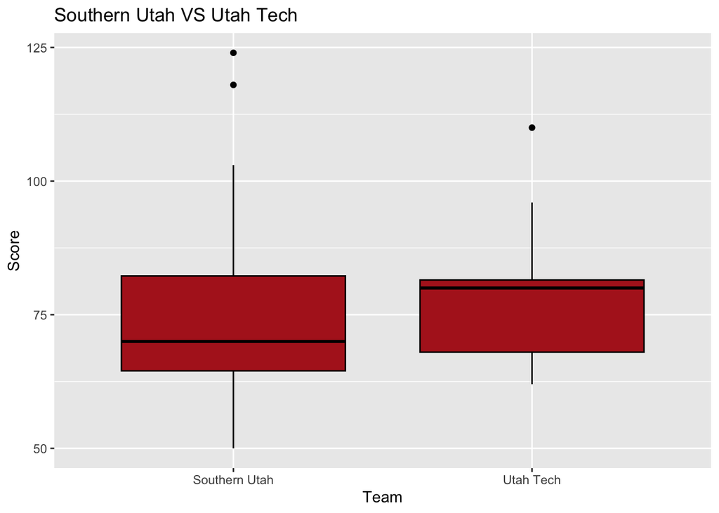

```r
teams_2 <- c("Utah Tech", "Southern Utah")
points <- cbbga_2025 |> filter(home_team %in% teams_2 | away_team %in% teams_2) |>
pivot_longer(cols = c(away_team, home_team),names_to = "side",values_to = "team") |>
mutate(points = if_else(side == "away_team", away_score, home_score)) |>
filter(team %in% teams_2) |>select(team, points)
ggbox <- function(x, group = NULL, horizontal = FALSE) {
if (!is.numeric(x)) {
    stop("x must be numeric")}
if (is.null(group)) {
    df <- data.frame(x = x)
    p <- ggplot(df, aes(y = x)) +
      geom_boxplot(fill = "firebrick", color = "black")
      } else {
    df <- data.frame(x = x, group = group)
    p <- ggplot(df, aes(x = group, y = x)) +
      geom_boxplot(fill = "firebrick", color = "black")}
if (horizontal) {
    p <- p + coord_flip()}
return(p)}
#| fig-width: 7
#| fig-height: 5.5
#| out-width: "80%"
#| fig-align: center
ggbox(points$points, group = points$team)+labs(x="Team",y="Score",title="Southern Utah VS Utah Tech")
```